# Review and Trend Analysis of Knowledge Graphs for Crop Pest and Diseases | IEEE Journals & Magazine | IEEE Xplore

## Application of the Knowledge Graph of Crop Diseases and Insect Pests

Knowledge graph provides a more effective way for the expression, organization, management and utilization of massive, heterogeneous, and dynamic large data information, which improves the level of intelligence and is closer to human cognitive thinking. At present, knowledge graph technology is mainly used in crop pest expert system, intelligent semantic search, crop pest knowledge question and answer.

### A. Expert System

Many expert systems have been early-developed for the diagnosis and control of crop diseases and insect pests, but only few have been popularized and applied, because the amount of knowledge in knowledge base is insufficient. Most of them can only realize the query function of knowledge. Essentially, they are only an information publishing system, and the intelligent range and decision-making ability of experts are difficult to surpass [66]. Traditional expert systems for crop diseases and pests have weak decision-making and reasoning abilities. For example, most expert systems for crop cultivation are knowledge- and rule-based, which cannot be closely integrated with crop growth models. The reasoning process of human experts can hardly be imitated. They only use the shallow knowledge of the system but lack dynamic prediction function and reasoning interpretation [67]. The expert system based on knowledge atlas technology solves the fundamental problem of the lack of correlation between crop pest knowledge and plays a great role in crop pest knowledge retrieval and visualization.

The knowledge map of crop diseases and insect pests not only provides data, model, and knowledge products, but also uses its own advantage of knowledge relevance to meet the needs of decision support. The expert system based on the knowledge map of crop diseases and insect pests is highly comprehensive, accurate, and scalable. In the future, more crop pest expert systems based on machine learning technology will provide a highly accurate decision support for crop pest prediction and diagnosis.

### B. Intelligent Semantic Search

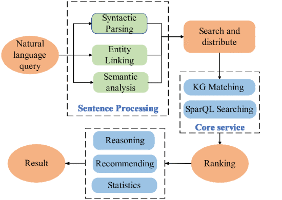

**FIGURE 11.**

Search engine framework based on knowledge graph.

Google took the lead in incorporating knowledge graph into search engines. The main domestic agricultural search engines are “Nongsou Search”, “Huanong Online”, and “Sounong Search”. Nongsou Search has 6 million agricultural cooperative websites, and achieves an intelligent search engine of full-text and semantic retrieval. Huanong Online uses natural language semantics analysis technology to realize information-processing application and realizes vertical search application in agricultural industry. The search engine for Sounong Search provides information retrieval of supply and demand, price, market dynamics, agricultural technology, video, news, diseases, insects, and weeds.

### C. Questions and Answering System

The knowledge map technology of crop diseases and insect pests can be applied to a new generation of agricultural system model and knowledge question-and-answer products, and can help accelerate agricultural innovation and meet the demand for the automatic acquisition of agricultural knowledge. At present, the methods used in question answering system mainly include the following:

1. Information-retrieval-based approach. It is a shallow semantic analysis method based on keyword matching and information extraction, which uses question information and knowledge base resources to obtain candidate answers.
2. Semantic parsing-based approach. Natural language questions are parsed into a logical form of expression through which the answers can be found from the knowledge base.
3. Modeling method based on vector space. Vector space is used to describe natural language questions and entities and relationships in knowledge maps. Question answering models are generated by machine and in-depth learning. Question answering system based on knowledge map maps the expression of natural language parsing into the vocabulary of knowledge map elements, which enhances the performance and expansibility of question answering system [79]. Figure 12 shows the flow chart of QA system based on knowledge map.

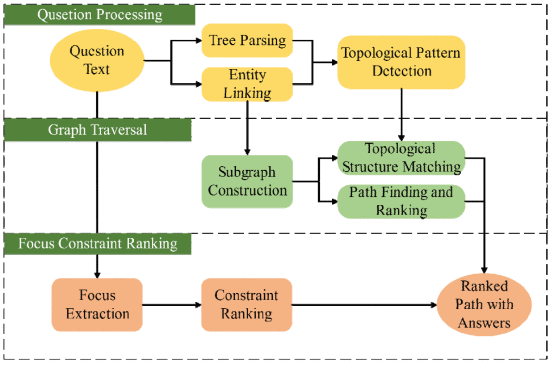

**FIGURE 12.**

Question and answering system architecture based on knowledge graph.

Hu *et al.* [80] joint disambiguation method is added to the question answer system based on a knowledge map, which improves query accuracy and query performance. Zhang *et al.* [81] proposed the architecture of deep learning and the application of end-to-end variational learning in knowledge-map-based question answering system, which can deal with multi-hop reasoning problems. Abdi *et al.* [82] integrated natural language processing, ontology, and information retrieval technology to develop knowledge question answering systems in physical fields. Yih *et al.* [83] applied entity link technology and deep convolution neural network model matching question and predicate sequence in question answering system, and greatly improved the system performance.

SECTION V.

## Conclusion

With the development of information technology, data in the field of crop diseases and insect pests have been accumulated. Constructing knowledge graph can improve the management, the extent of sharing and application of crop pest and diseases knowledge. The development of intelligent agriculture and precision agriculture is greatly significant and is also a future research hotspot. In this paper, the background, technology, and application of knowledge map of crop diseases and insect pests were summarized from the perspective of the application of knowledge map in crop diseases and insect pests. The main challenges faced by the knowledge map of crop diseases and insect pests were summarized, and future research directions were prospected. The combination of knowledge atlas and pest knowledge will promote the automation and intellectualization of crop pest and disease related systems. Many attempts have been made to study the knowledge map of crop diseases and insect pests, but they were not perfect and in-depth, and require further research. In the future, the knowledge map of crop diseases and insect pests can be deeply studied from the following aspects:

1. implement the overall solution to improve the quality of knowledge maps;
2. explore how the knowledge map can be extended and the general method of knowledge map construction;
3. implement and establish the evaluation criteria of the knowledge atlas in the field of pests and diseases; and
4. achieve fast and accurate construction of large-scale domain knowledge map.

With the emergence of large-scale networks, the expansion and automation of knowledge map will be the trend of future developments in this field.

# References

**1.**

H. Arnaout and S. Elbassuoni, "Effective searching of RDF knowledge graphs", *J. Web Semantics*, vol. 48, pp. 66-84, Jan. 2018.

Show in Context [CrossRef](https://doi.org/10.1016/j.websem.2017.12.001) [Google Scholar](https://scholar.google.com/scholar?as_q=Effective+searching+of+RDF+knowledge+graphs&as_occt=title&hl=en&as_sdt=0%2C31)

**2.**

C. B. Wang, X. Ma, J. Chen and J. Chen, "Information extraction and knowledge graph construction from geoscience literature", *Comput. Geosci.*, vol. 112, pp. 112-120, Mar. 2018.

Show in Context [CrossRef](https://doi.org/10.1016/j.cageo.2017.12.007) [Google Scholar](https://scholar.google.com/scholar?as_q=Information+extraction+and+knowledge+graph+construction+from+geoscience+literature&as_occt=title&hl=en&as_sdt=0%2C31)

**3.**

P. K. Thornton et al., "Site selection to test an integrated approach to agricultural research for development: Combining expert knowledge and participatory geographic information system methods", *Int. J. Agricult. Sustainability*, vol. 4, pp. 39-60, 2006.

Show in Context [CrossRef](https://doi.org/10.1080/14735903.2006.9686008) Google Scholar

**4.**

M. M. Yusof, N. F. Rosli, M. Othman, R. Mohamed and M. H. A. Abdullah, "M-DCocoa: M-agriculture expert system for diagnosing cocoa plant diseases" in Recent Advances on Soft Computing and Data Mining, Cham, Switzerland:Springer, vol. 700, 2018.

Show in Context [CrossRef](https://doi.org/10.1007/978-3-319-72550-5_35) [Google Scholar](https://scholar.google.com/scholar?as_q=M-DCocoa%3A+M-agriculture+expert+system+for+diagnosing+cocoa+plant+diseases&as_occt=title&hl=en&as_sdt=0%2C31)

**5.**

Y. Yao and W. Xu, "Construction of ontology knowledge base for water and soil conservation measures suitability evaluation" in Journal of Fuzhou University, pp. 188-195, 2016.

Show in Context [Google Scholar](https://scholar.google.com/scholar?as_q=Construction+of+ontology+knowledge+base+for+water+and+soil+conservation+measures+suitability+evaluation&as_occt=title&hl=en&as_sdt=0%2C31)

**6.**

W. D. van Eeden, J. P. de Villiers, R. J. Berndt, W. A. J. Nel and E. Blasch, "Micro-Doppler radar classification of humans and animals in an operational environment", *Expert Syst. Appl.*, vol. 102, pp. 1-11, Jul. 2018.

Show in Context [CrossRef](https://doi.org/10.1016/j.eswa.2018.02.019) [Google Scholar](https://scholar.google.com/scholar?as_q=Micro-Doppler+radar+classification+of+humans+and+animals+in+an+operational+environment&as_occt=title&hl=en&as_sdt=0%2C31)

**7.**

B. Stewart-Koster et al., "Expert based model building to quantify risk factors in a combined aquaculture-agriculture system", *Agricult. Syst.*, vol. 157, pp. 230-240, Oct. 2017.

Show in Context [CrossRef](https://doi.org/10.1016/j.agsy.2017.08.001) [Google Scholar](https://scholar.google.com/scholar?as_q=Expert+based+model+building+to+quantify+risk+factors+in+a+combined+aquaculture-agriculture+system&as_occt=title&hl=en&as_sdt=0%2C31)

**8.**

Z. Xu, Y. P. Sheng, L. R. He and Y. F. Wang, "Review on knowledge graph techniques", *J. Univ. Electron. Sci. Technol. China*, vol. 45, no. 4, pp. 589-606, 2016.

Show in Context [Google Scholar](https://scholar.google.com/scholar?as_q=Review+on+knowledge+graph+techniques&as_occt=title&hl=en&as_sdt=0%2C31)

**9.**

L. Qiao, L. Yang, D. Hong, L. Yao and Q. Zhiguang, "Knowledge graph construction techniques", *J. Comput. Res. Develop.*, vol. 53, no. 3, pp. 582-600, 2016.

Show in Context [Google Scholar](https://scholar.google.com/scholar?as_q=Knowledge+graph+construction+techniques&as_occt=title&hl=en&as_sdt=0%2C31)

**10.**

T. Yu et al., "Knowledge graph for TCM health preservation: Design construction and applications", *Artif. Intell. Med.*, vol. 77, pp. 48-52, Mar. 2017.

Show in Context [CrossRef](https://doi.org/10.1016/j.artmed.2017.04.001) [Google Scholar](https://scholar.google.com/scholar?as_q=Knowledge+graph+for+TCM+health+preservation%3A+Design%2C+construction%2C+and+applications&as_occt=title&hl=en&as_sdt=0%2C31)

**11.**

J. L. Martinez-Rodriguez, I. Lopez-Arevalo and A. B. Rios-Alvarado, "OpenIE-based approach for knowledge graph construction from text", *Expert Syst. Appl.*, vol. 113, pp. 339-355, Dec. 2018.

Show in Context [CrossRef](https://doi.org/10.1016/j.eswa.2018.07.017) [Google Scholar](https://scholar.google.com/scholar?as_q=OpenIE-based+approach+for+knowledge+graph+construction+from+text&as_occt=title&hl=en&as_sdt=0%2C31)

**12.**

X. Zhang, X. Liu, X. Li and D. Pan, "MMKG: An approach to generate metallic materials knowledge graph based on DBpedia and Wikipedia", *Comput. Phys. Commun.*, vol. 211, pp. 98-112, Feb. 2017.

Show in Context [CrossRef](https://doi.org/10.1016/j.cpc.2016.07.005) [Google Scholar](https://scholar.google.com/scholar?as_q=MMKG%3A+An+approach+to+generate+metallic+materials+knowledge+graph+based+on+DBpedia+and+Wikipedia&as_occt=title&hl=en&as_sdt=0%2C31)

**13.**

C. Dong, "Design and implementation of forest management knowledge service system based on frame representation", *J. Zhejiang A F Univ.*, vol. 34, no. 3, pp. 491-500, 2017.

Show in Context [Google Scholar](https://scholar.google.com/scholar?as_q=Design+and+implementation+of+forest+management+knowledge+service+system+based+on+frame+representation&as_occt=title&hl=en&as_sdt=0%2C31)

**14.**

Z. Shaohua, "Object-oriented representation for owl ontology knowledge base", *Softw. Eng. Appl.*, vol. 07, pp. 132-141, 2018.

Show in Context [Google Scholar](https://scholar.google.com/scholar?as_q=Object-oriented+representation+for+owl+ontology+knowledge+base&as_occt=title&hl=en&as_sdt=0%2C31)

**15.**

J. Dou, J. Qin, Z. Jin and Z. Li, "Knowledge graph based on domain ontology and natural language processing technology for Chinese intangible cultural heritage", *J. Vis. Lang. Comput.*, vol. 48, pp. 19-28, Oct. 2018.

Show in Context [CrossRef](https://doi.org/10.1016/j.jvlc.2018.06.005) [Google Scholar](https://scholar.google.com/scholar?as_q=Knowledge+graph+based+on+domain+ontology+and+natural+language+processing+technology+for+Chinese+intangible+cultural+heritage&as_occt=title&hl=en&as_sdt=0%2C31)

**16.**

Y. Wang, Y. Wang, J. Wang, Y. Yuan and Z. Zhang, "An ontology-based approach to integration of hilly citrus production knowledge", *Comput. Electron. Agricult.*, vol. 113, pp. 24-43, Apr. 2015.

Show in Context [CrossRef](https://doi.org/10.1016/j.compag.2015.01.009) [Google Scholar](https://scholar.google.com/scholar?as_q=An+ontology-based+approach+to+integration+of+hilly+citrus+production+knowledge&as_occt=title&hl=en&as_sdt=0%2C31)

**17.**

A. Chougule, V. K. Jha and D. Mukhopadhyay, "Adaptive ontology construction method for crop pest management", *Proc. Int. Conf. Data Eng. Commun. Technol.*, pp. 665-674, 2016.

Show in Context [Google Scholar](https://scholar.google.com/scholar?as_q=Adaptive+ontology+construction+method+for+crop+pest+management&as_occt=title&hl=en&as_sdt=0%2C31)

**18.**

J. Cañadas, I. M. del Águila and J. Palma, "Development of a web tool for action threshold evaluation in table grape pest management", *Precis. Agricult.*, vol. 18, pp. 974-996, Dec. 2017.

Show in Context [CrossRef](https://doi.org/10.1007/s11119-016-9487-0) [Google Scholar](https://scholar.google.com/scholar?as_q=Development+of+a+web+tool+for+action+threshold+evaluation+in+table+grape+pest+management&as_occt=title&hl=en&as_sdt=0%2C31)

**19.**

K. Lagos-Ortiz et al., "An ontology-based decision support system for insect pest control in crops", *Proc. Int. Conf. Technol. Innov.*, 2018.

Show in Context [CrossRef](https://doi.org/10.1007/978-3-030-00940-3_1) [Google Scholar](https://scholar.google.com/scholar?as_q=An+ontology-based+decision+support+system+for+insect+pest+control+in+crops&as_occt=title&hl=en&as_sdt=0%2C31)

**20.**

N. Guan, D. Song and L. Liao, "Knowledge graph embedding with concepts", *Knowl.-Based Syst.*, vol. 164, pp. 38-44, Jan. 2019.

Show in Context [CrossRef](https://doi.org/10.1016/j.knosys.2018.10.008) [Google Scholar](https://scholar.google.com/scholar?as_q=Knowledge+graph+embedding+with+concepts&as_occt=title&hl=en&as_sdt=0%2C31)

**21.**

W. L. Hamilton, R. Ying and J. Leskovec, "Inductive representation learning on large graphs", 2017.

Show in Context [Google Scholar](https://scholar.google.com/scholar?as_q=Inductive+representation+learning+on+large+graphs&as_occt=title&hl=en&as_sdt=0%2C31)

**22.**

Y. Zuo, Q. Fang, S. Qian, X. Zhang and C. Xu, "Representation learning of knowledge graphs with entity attributes and multimedia descriptions", *Proc. IEEE 4th Int. Conf. Multimedia Big Data (BigMM)*, pp. 1-5, Sep. 2018.

Show in Context [View Article](https://ieeexplore.ieee.org/document/8499179)

[Google Scholar](https://scholar.google.com/scholar?as_q=Representation+learning+of+knowledge+graphs+with+entity+attributes+and+multimedia+descriptions&as_occt=title&hl=en&as_sdt=0%2C31)

**23.**

W. L. Hamilton, R. Ying and J. Leskovec, "Representation learning on graphs: Methods and applications", *IEEE Data Eng. Bull.*.

Show in Context [Google Scholar](https://scholar.google.com/scholar?as_q=Representation+learning+on+graphs%3A+Methods+and+applications&as_occt=title&hl=en&as_sdt=0%2C31)

**24.**

W. J. Vlietstra et al., "Automated extraction of potential migraine biomarkers using a semantic graph", *J. Biomed. Informat.*, vol. 71, pp. 178-189, Jul. 2017.

Show in Context [CrossRef](https://doi.org/10.1016/j.jbi.2017.05.018) [Google Scholar](https://scholar.google.com/scholar?as_q=Automated+extraction+of+potential+migraine+biomarkers+using+a+semantic+graph&as_occt=title&hl=en&as_sdt=0%2C31)

**25.**

G. Zhu and C. A. Iglesias, "Exploiting semantic similarity for named entity disambiguation in knowledge graphs", *Expert Syst. Appl.*, vol. 101, pp. 8-24, Jul. 2018.

Show in Context [CrossRef](https://doi.org/10.1016/j.eswa.2018.02.011) [Google Scholar](https://scholar.google.com/scholar?as_q=Exploiting+semantic+similarity+for+named+entity+disambiguation+in+knowledge+graphs&as_occt=title&hl=en&as_sdt=0%2C31)

**26.**

Z. Zhou, J. Yang, Y. Qi and Y. Cai, "Support vector machine and back propagation neutral network approaches for trip mode prediction using mobile phone data", *IET Intell. Transp. Syst.*, vol. 12, no. 10, pp. 1220-1226, 2018.

Show in Context [CrossRef](https://doi.org/10.1049/iet-its.2018.5203) [Google Scholar](https://scholar.google.com/scholar?as_q=Support+vector+machine+and+back+propagation+neutral+network+approaches+for+trip+mode+prediction+using+mobile+phone+data&as_occt=title&hl=en&as_sdt=0%2C31)

**27.**

L. Xiang, W. Xiaohong, J. Lu, C. Xin, L. Lei and Z. Yan, "Recognition of cropsdiseases and pesticides named entitiesin chinese based on conditional random fields", *Trans. Chin. Soc. Agricult.*, vol. 48, no. S1, pp. 178-185, 2017.

Show in Context [Google Scholar](https://scholar.google.com/scholar?as_q=Recognition+of+crops%2Cdiseases+and+pesticides+named+entitiesin+chinese+based+on+conditional+random+fields&as_occt=title&hl=en&as_sdt=0%2C31)

**28.**

F. Ying, "Research on application of C-CRF model on named entity recognition of the agricultural product", *Guangdong Agricult. Sci.*, vol. 38, pp. 197-199, 2011.

[Google Scholar](https://scholar.google.com/scholar?as_q=Research+on+application+of+C-CRF+model+on+named+entity+recognition+of+the+agricultural+product&as_occt=title&hl=en&as_sdt=0%2C31)

**29.**

C. Wang and F. Wang, "Study on recognition of Chinese agricultural named entity with confitional random fields", *J. Agricult. Univ. Hebei*, vol. 37, no. 1, pp. 132-135, 2014.

[Google Scholar](https://scholar.google.com/scholar?as_q=Study+on+recognition+of+Chinese+agricultural+named+entity+with+confitional+random+fields&as_occt=title&hl=en&as_sdt=0%2C31)

**30.**

Z. Jian et al., "Chinese agricultural named entity recognition based on conditional random fields", *Jisuanji Yu Xiandaihua*, no. 1, pp. 123-126, 2018.

[Google Scholar](https://scholar.google.com/scholar?as_q=Chinese+agricultural+named+entity+recognition+based+on+conditional+random+fields&as_occt=title&hl=en&as_sdt=0%2C31)

**31.**

T. H. Dang, H.-Q. Le, T. M. Nguyen and S. T. Vu, "D3NER: Biomedical named entity recognition using CRF-biLSTM improved with fine-tuned embeddings of various linguistic information", *Bioinformatics*, vol. 34, no. 20, pp. 3539-3546, 2018.

Show in Context [CrossRef](https://doi.org/10.1093/bioinformatics/bty356) [Google Scholar](https://scholar.google.com/scholar?as_q=D3NER%3A+Biomedical+named+entity+recognition+using+CRF-biLSTM+improved+with+fine-tuned+embeddings+of+various+linguistic+information&as_occt=title&hl=en&as_sdt=0%2C31)

**32.**

R. Kadari, Y. Zhang, W. Zhang and T. Liu, "CCG supertagging via bidirectional LSTM-CRF neural architecture", *Neurocomputing*, vol. 283, pp. 31-37, Mar. 2018.

Show in Context [CrossRef](https://doi.org/10.1016/j.neucom.2017.12.050) [Google Scholar](https://scholar.google.com/scholar?as_q=CCG+supertagging+via+bidirectional+LSTM-CRF+neural+architecture&as_occt=title&hl=en&as_sdt=0%2C31)

**33.**

V. Devisree and P. C. R. Raj, "A hybrid approach to relationship extraction from stories", *Procedia Technol.*, vol. 24, pp. 1499-1506, 2016.

Show in Context [CrossRef](https://doi.org/10.1016/j.protcy.2016.05.101) [Google Scholar](https://scholar.google.com/scholar?as_q=A+hybrid+approach+to+relationship+extraction+from+stories&as_occt=title&hl=en&as_sdt=0%2C31)

**34.**

M. Nickel, K. Murphy, V. Tresp and E. Gabrilovich, "A review of relational machine learning for knowledge graphs", *Proc. IEEE*, vol. 104, no. 1, pp. 11-33, Jan. 2016.

Show in Context [View Article](https://ieeexplore.ieee.org/document/7358050)

[Google Scholar](https://scholar.google.com/scholar?as_q=A+review+of+relational+machine+learning+for+knowledge+graphs&as_occt=title&hl=en&as_sdt=0%2C31)

**35.**

N. Kaushik and N. Chatterjee, "Automatic relationship extraction from agricultural text for ontology construction", *Inf. Process. Agricult.*, vol. 5, no. 1, pp. 60-73, 2018.

Show in Context [CrossRef](https://doi.org/10.1016/j.inpa.2017.11.003) [Google Scholar](https://scholar.google.com/scholar?as_q=Automatic+relationship+extraction+from+agricultural+text+for+ontology+construction&as_occt=title&hl=en&as_sdt=0%2C31)

**36.**

M. Shuyue, "Axioms extraction method of the non-taxonomic relationship in crop diseases and insect pests", *Comput. Digit. Eng.*, vol. 43, no. 10, pp. 1746-1750, 2015.

Show in Context [Google Scholar](https://scholar.google.com/scholar?as_q=Axioms+extraction+method+of+the+non-taxonomic+relationship+in+crop+diseases+and+insect+pests&as_occt=title&hl=en&as_sdt=0%2C31)

**37.**

Z. Ming, D. Yaru, D. Huifang, Z. Jiajun, W. Hongshuo and C. Ying, "Research on ontology non-taxonomic relations extraction in plant domain knowledge graph construction", *Trans. Chin. Soc. Agricult. Machinery*, vol. 47, no. 9, pp. 9-38, 2016.

Show in Context [Google Scholar](https://scholar.google.com/scholar?as_q=Research+on+ontology+non-taxonomic+relations+extraction+in+plant+domain+knowledge+graph+construction&as_occt=title&hl=en&as_sdt=0%2C31)

**38.**

A. Fader, S. Soderland and O. Etzioni, "Identifying relations for open information extraction", *Proc. Conf. Empirical Methods Natural Lang. Process.*, pp. 1535-1545, 2011.

[Google Scholar](https://scholar.google.com/scholar?as_q=Identifying+relations+for+open+information+extraction&as_occt=title&hl=en&as_sdt=0%2C31)

**39.**

D. Zelenko, C. Aone and A. Richardella, "Kernel methods for relation extraction", *J. Mach. Learn. Res.*, vol. 3, pp. 1083-1106, Feb. 2003.

[Google Scholar](https://scholar.google.com/scholar?as_q=Kernel+methods+for+relation+extraction&as_occt=title&hl=en&as_sdt=0%2C31)

**40.**

N. Kambhatla, "Combining lexical syntactic and semantic features with maximum entropy models for extracting relations", *Proc. ACL*, pp. 1-4, 2004.

[CrossRef](https://doi.org/10.3115/1219044.1219066) [Google Scholar](https://scholar.google.com/scholar?as_q=Combining+lexical%2C+syntactic%2C+and+semantic+features+with+maximum+entropy+models+for+extracting+relations&as_occt=title&hl=en&as_sdt=0%2C31)

**41.**

S. Miller, H. Fox, L. Ramshaw and R. Weischedel, "A novel use of statistical parsing to extract information from text", *Proc. HLT-NAACL*, pp. 1-8, 2006.

[Google Scholar](https://scholar.google.com/scholar?as_q=A+novel+use+of+statistical+parsing+to+extract+information+from+text&as_occt=title&hl=en&as_sdt=0%2C31)

**42.**

A. Culotta, A. McCallum and J. Betz, "Integrating probabilistic extraction models and data mining to discover relations and patterns in text", *Proc. Hum. Lang. Technol. Conf. North Amer. Chapter ACL*, pp. 296-303, 2006.

[CrossRef](https://doi.org/10.3115/1220835.1220873) [Google Scholar](https://scholar.google.com/scholar?as_q=Integrating+probabilistic+extraction+models+and+data+mining+to+discover+relations+and+patterns+in+text&as_occt=title&hl=en&as_sdt=0%2C31)

**43.**

B. Min, R. Grishman, L. Wan, C. Wang and D. Gondek, "Distant supervision for relation extraction with an incomplete knowledge base", *Proc. NAACL-HLT*, pp. 1-6, 2013.

[Google Scholar](https://scholar.google.com/scholar?as_q=Distant+supervision+for+relation+extraction+with+an+incomplete+knowledge+base&as_occt=title&hl=en&as_sdt=0%2C31)

**44.**

S. Takamatsu, "Reducing wrong labels in distant supervision for relation extraction", *Proc. ACL*, pp. 721-729, 2012.

[Google Scholar](https://scholar.google.com/scholar?as_q=Reducing+wrong+labels+in+distant+supervision+for+relation+extraction&as_occt=title&hl=en&as_sdt=0%2C31)

**45.**

L. Yao, S. Riedel and A. McCallum, "Collective cross-document relation extraction without labelled data", *Proc. EMNLP*, pp. 1013-1023, 2010.

[Google Scholar](https://scholar.google.com/scholar?as_q=Collective+cross-document+relation+extraction+without+labelled+data&as_occt=title&hl=en&as_sdt=0%2C31)

**46.**

M. Surdeanu, J. Tibshirani, R. Nallapati and C. D. Manning, "Multi-instance multi-label learning for relation extraction", *Proc. ACL-HLT*, pp. 455-465, 2011.

[Google Scholar](https://scholar.google.com/scholar?as_q=Multi-instance+multi-label+learning+for+relation+extraction&as_occt=title&hl=en&as_sdt=0%2C31)

**47.**

C. N. D. Santos, B. Xiang and B. Zhou, "Classifying relations by ranking with convolutional neural networks", *Comput. Sci.*, vol. 86, no. 86, pp. 132-137, 2015.

[CrossRef](https://doi.org/10.3115/v1/P15-1061) [Google Scholar](https://scholar.google.com/scholar?as_q=Classifying+relations+by+ranking+with+convolutional+neural+networks&as_occt=title&hl=en&as_sdt=0%2C31)

**48.**

M. Miwa and M. Bansal, "End-to-end relation extraction using LSTMs on sequences and tree structures", 2016.

[CrossRef](https://doi.org/10.18653/v1/P16-1105) [Google Scholar](https://scholar.google.com/scholar?as_q=End-to-end+relation+extraction+using+LSTMs+on+sequences+and+tree+structures&as_occt=title&hl=en&as_sdt=0%2C31)

**49.**

X. Zhang, F. Chen and R. Huang, "A combination of RNN and CNN for attention-based relation classification", *Procedia Comput. Sci.*, vol. 131, pp. 911-917, 2018.

[CrossRef](https://doi.org/10.1016/j.procs.2018.04.221) [Google Scholar](https://scholar.google.com/scholar?as_q=A+combination+of+RNN+and+CNN+for+attention-based+relation+classification&as_occt=title&hl=en&as_sdt=0%2C31)

**50.**

P. Zhou, J. Xu, Z. Qi, H. Bao, Z. Chen and B. Xu, "Distant supervision for relation extraction with hierarchical selective attention", *Neural Netw.*, vol. 108, pp. 240-247, Dec. 2018.

[CrossRef](https://doi.org/10.1016/j.neunet.2018.08.016) [Google Scholar](https://scholar.google.com/scholar?as_q=Distant+supervision+for+relation+extraction+with+hierarchical+selective+attention&as_occt=title&hl=en&as_sdt=0%2C31)

**51.**

H. Qichen and Z. Yawei, "Initial seed set automatic generation algorithm for domain knowledge graph based on thesaurus", *J. Chin. Inf. Process.*, vol. 32, no. 8, pp. 1-8, 2018.

Show in Context [Google Scholar](https://scholar.google.com/scholar?as_q=Initial+seed+set+automatic+generation+algorithm+for+domain+knowledge+graph+based+on+thesaurus&as_occt=title&hl=en&as_sdt=0%2C31)

**52.**

W. Liu et al., "Representation learning over multiple knowledge graphs for knowledge graphs alignment", *Neurocomputing*, vol. 320, pp. 12-24, Dec. 2018.

Show in Context [CrossRef](https://doi.org/10.1016/j.neucom.2018.08.070) [Google Scholar](https://scholar.google.com/scholar?as_q=Representation+learning+over+multiple+knowledge+graphs+for+knowledge+graphs+alignment&as_occt=title&hl=en&as_sdt=0%2C31)

**53.**

A. Annane, Z. Bellahsene, F. Azouaou and C. Jonquet, "Building an effective and efficient background knowledge resource to enhance ontology matching", *J. Web Semantics*, vol. 51, pp. 51-68, Aug. 2018.

Show in Context [CrossRef](https://doi.org/10.1016/j.websem.2018.04.001) [Google Scholar](https://scholar.google.com/scholar?as_q=Building+an+effective+and+efficient+background+knowledge+resource+to+enhance+ontology+matching&as_occt=title&hl=en&as_sdt=0%2C31)

**54.**

G. Zhu and C. A. Iglesias, "Sematch: Semantic similarity framework for knowledge graphs", *Knowl.-Based Syst.*, vol. 130, pp. 30-32, Aug. 2017.

Show in Context [CrossRef](https://doi.org/10.1016/j.knosys.2017.05.021) [Google Scholar](https://scholar.google.com/scholar?as_q=Sematch%3A+Semantic+similarity+framework+for+knowledge+graphs&as_occt=title&hl=en&as_sdt=0%2C31)

**55.**

X. Xue and X. Yao, "Interactive ontology matching based on partial reference alignment", *Appl. Soft Comput.*, vol. 72, pp. 355-370, Nov. 2018.

Show in Context [CrossRef](https://doi.org/10.1016/j.asoc.2018.08.003) [Google Scholar](https://scholar.google.com/scholar?as_q=Interactive+ontology+matching+based+on+partial+reference+alignment&as_occt=title&hl=en&as_sdt=0%2C31)

**56.**

M. Chen, Y. Tian, K. W. Chang, S. Skiena and C. Zaniolo, "Co-training embeddings of knowledge graphs and entity descriptions for cross-lingual entity alignment", 2018.

Show in Context [CrossRef](https://doi.org/10.24963/ijcai.2018/556) [Google Scholar](https://scholar.google.com/scholar?as_q=Co-training+embeddings+of+knowledge+graphs+and+entity+descriptions+for+cross-lingual+entity+alignment&as_occt=title&hl=en&as_sdt=0%2C31)

**57.**

F. Yang, Z. Yang and W. W. Cohen, "Differentiable learning of logical rules for knowledge base reasoning", *Proc. Adv. Neural Inf. Process. Syst.*, pp. 2319-2328, 2017.

Show in Context [Google Scholar](https://scholar.google.com/scholar?as_q=Differentiable+learning+of+logical+rules+for+knowledge+base+reasoning&as_occt=title&hl=en&as_sdt=0%2C31)

**58.**

B. Kamsu-Foguem, F. H. Abanda, M. B. Doumbouya and J. F. Tchouanguem, "Graph-based ontology reasoning for formal verification of BREEAM rules", *Cognit. Syst. Res.*, vol. 55, pp. 14-33, Jun. 2019.

Show in Context [CrossRef](https://doi.org/10.1016/j.cogsys.2018.12.011) [Google Scholar](https://scholar.google.com/scholar?as_q=Graph-based+ontology+reasoning+for+formal+verification+of+BREEAM+rules&as_occt=title&hl=en&as_sdt=0%2C31)

**59.**

F. Lecue and J. Wu, "Explaining and predicting abnormal expenses at large scale using knowledge graph based reasoning", *J. Web Semantics*, vol. 44, pp. 89-103, May 2017.

Show in Context [CrossRef](https://doi.org/10.1016/j.websem.2017.05.003) [Google Scholar](https://scholar.google.com/scholar?as_q=Explaining+and+predicting+abnormal+expenses+at+large+scale+using+knowledge+graph+based+reasoning&as_occt=title&hl=en&as_sdt=0%2C31)

**60.**

W. Juan, "Research of tobacco disease prevention and control model based on case study reasoning and knowledge map", 2016.

Show in Context [Google Scholar](https://scholar.google.com/scholar?as_q=Research+of+tobacco+disease+prevention+and+control+model+based+on+case+study+reasoning+and+knowledge+map&as_occt=title&hl=en&as_sdt=0%2C31)

**61.**

D. López-Sánchez, J. M. Corchado and A. G. Arrieta, "A CBR system for image-based webpage classification: Case representation with convolutional neural networks", *Proc. 13th Int. Florida Artif. Intell. Res. Soc. Conf.*, pp. 1-6, 2017.

Show in Context [Google Scholar](https://scholar.google.com/scholar?as_q=A+CBR+system+for+image-based+webpage+classification%3A+Case+representation+with+convolutional+neural+networks&as_occt=title&hl=en&as_sdt=0%2C31)

**62.**

S. Y. Sharma, D. P. Roy and B. Chakraborty, "Health services support system (HESS): An ontology supported CBR system for cognitive diagnosis applied on HIV/AIDS detection", *Proc. 2nd Int. Conf. Comput. Sustain. Global Develop.*, pp. 284-290, Mar. 2015.

Show in Context [Google Scholar](https://scholar.google.com/scholar?as_q=Health+services+support+system+%28HESS%29%3A+An+ontology+supported+CBR+system+for+cognitive+diagnosis+applied+on+HIV%2FAIDS+detection&as_occt=title&hl=en&as_sdt=0%2C31)

**63.**

S. Hao, "Clivia plant diseases and pests’ diagnosis model building and the realization of intelligent expert system", 2015.

Show in Context [Google Scholar](https://scholar.google.com/scholar?as_q=Clivia+plant+diseases+and+pests%E2%80%99+diagnosis+model+building+and+the+realization+of+intelligent+expert+system&as_occt=title&hl=en&as_sdt=0%2C31)

**64.**

C. Liping, Y. Maishun and L. Xiaodong, "Reasoning mechanism of wheat irrigating expert system for rational use of water", *Comput. Eng. Appl.*, vol. 40, pp. 216-219, 2004.

Show in Context [Google Scholar](https://scholar.google.com/scholar?as_q=Reasoning+mechanism+of+wheat+irrigating+expert+system+for+rational+use+of+water&as_occt=title&hl=en&as_sdt=0%2C31)

**65.**

M. Bo, L. Junchen and W. Na, "Design and realization of the maize disease diagnosis system based on image rules", *J. Maize Sci.*, vol. 17, no. 6, pp. 132-135, 2009.

Show in Context [Google Scholar](https://scholar.google.com/scholar?as_q=Design+and+realization+of+the+maize+disease+diagnosis+system+based+on+image+rules&as_occt=title&hl=en&as_sdt=0%2C31)

**66.**

G. Blondet, J. Le Duigou and N. Boudaoud, "A knowledge-based system for numerical design of experiments processes in mechanical engineering", *Expert Syst. Appl.*, vol. 122, pp. 289-302, May 2019.

Show in Context [CrossRef](https://doi.org/10.1016/j.eswa.2019.01.013) [Google Scholar](https://scholar.google.com/scholar?as_q=A+knowledge-based+system+for+numerical+design+of+experiments+processes+in+mechanical+engineering&as_occt=title&hl=en&as_sdt=0%2C31)

**67.**

J. Gu, H. Wui and X. Sun, Realization of the Cross-Platform Agriculture Expert System With Java and JESS, ISIITA, pp. 323-327, 2007.

Show in Context [Google Scholar](https://scholar.google.com/scholar?as_q=Realization+of+the+Cross-Platform+Agriculture+Expert+System+With+Java+and+JESS&as_occt=title&hl=en&as_sdt=0%2C31)

**68.**

L. R. Haidar, I. M. I. Subroto and A. Marwanto, "Expert system on soybean disease using knowledge representation method", *J. Telematics Inform.*, vol. 5, no. 1, pp. 36-46, 2017.

Show in Context [Google Scholar](https://scholar.google.com/scholar?as_q=Expert+system+on+soybean+disease+using+knowledge+representation+method&as_occt=title&hl=en&as_sdt=0%2C31)

**69.**

D. A. Nascimento, R. M. Anunciação, A. Arnhold, A. C. F. Filho, A. D. Santos and J. C. Zanuncio, "Expert system for identification of economically important insect pests in commercial teak plantations", *Comput. Electron. Agricult.*, vol. 121, pp. 368-373, Feb. 2016.

Show in Context [CrossRef](https://doi.org/10.1016/j.compag.2015.12.024) [Google Scholar](https://scholar.google.com/scholar?as_q=Expert+system+for+identification+of+economically+important+insect+pests+in+commercial+teak+plantations&as_occt=title&hl=en&as_sdt=0%2C31)

**70.**

W. R. Mendes, F. M. U. Araújo, R. Dutta and D. M. Heeren, "Fuzzy control system for variable rate irrigation using remote sensing", *Expert Syst. Appl.*, vol. 124, pp. 13-24, Jun. 2019.

Show in Context [CrossRef](https://doi.org/10.1016/j.eswa.2019.01.043) [Google Scholar](https://scholar.google.com/scholar?as_q=Fuzzy+control+system+for+variable+rate+irrigation+using+remote+sensing&as_occt=title&hl=en&as_sdt=0%2C31)

**71.**

R. Rahim, N. N. D. S and M. Zamroni, "Pest plant disease prevention and identification system using certainty factor method", *Int. J. Eng. Technol.*, vol. 7, pp. 763-765, 2018.

Show in Context [CrossRef](https://doi.org/10.14419/ijet.v7i3.2.18750) [Google Scholar](https://scholar.google.com/scholar?as_q=Pest+plant+disease+prevention+and+identification+system+using+certainty+factor+method&as_occt=title&hl=en&as_sdt=0%2C31)

**72.**

H. Kalita, S. K. Sarma and R. D. Choudhury, "Expert system for diagnosis of diseases of rice plants: Prototype design and implementation", *Proc. Int. Conf. Autom. Control Dyn. Optim. Techn.*, pp. 723-730, Sep. 2016.

Show in Context [View Article](https://ieeexplore.ieee.org/document/7877682)

[Google Scholar](https://scholar.google.com/scholar?as_q=Expert+system+for+diagnosis+of+diseases+of+rice+plants%3A+Prototype+design+and+implementation&as_occt=title&hl=en&as_sdt=0%2C31)

**73.**

R. Ballot et al., "First cropping system model based on expert-knowledge parameterization", *Agronomy Sustain. Develop.*, vol. 38, pp. 33, Jun. 2018.

Show in Context [CrossRef](https://doi.org/10.1007/s13593-018-0512-8) [Google Scholar](https://scholar.google.com/scholar?as_q=First+cropping+system+model+based+on+expert-knowledge+parameterization&as_occt=title&hl=en&as_sdt=0%2C31)

**74.**

P. Damos, "Modular structure of web-based decision support systems for integrated pest management. A review", *Agronomy Sustain. Develop.*, vol. 35, pp. 1347-1372, Oct. 2015.

Show in Context [CrossRef](https://doi.org/10.1007/s13593-015-0319-9) [Google Scholar](https://scholar.google.com/scholar?as_q=Modular+structure+of+web-based+decision+support+systems+for+integrated+pest+management.+A+review&as_occt=title&hl=en&as_sdt=0%2C31)

**75.**

A. Babalola, O. Abiodun, F. Aderanti and A. John, "Development of a Web based expert system for managing pests and diseases of moringa oleifera" in Engineering and Information Technology, CSEIT, 2018.

Show in Context [Google Scholar](https://scholar.google.com/scholar?as_q=Development+of+a+Web+based+expert+system+for+managing+pests+and+diseases+of+moringa+oleifera&as_occt=title&hl=en&as_sdt=0%2C31)

**76.**

E. Lasso and J. C. Corrales, "Towards an alert system for coffee diseases and pests in a smart farming approach based on semi-supervised learning and graph similarity", *Proc. Int. Conf. ICT Adapting Agricult. Climate Change*, 2017.

Show in Context Google Scholar

**77.**

M. Arenas, B. C. Grau, E. Kharlamov, Š. Marciuška and D. Zheleznyakov, "Faceted search over RDF-based knowledge graphs", *J. Web Semantics*, vol. 37, pp. 55-74, Mar. 2016.

Show in Context [CrossRef](https://doi.org/10.1016/j.websem.2015.12.002) [Google Scholar](https://scholar.google.com/scholar?as_q=Faceted+search+over+RDF-based+knowledge+graphs&as_occt=title&hl=en&as_sdt=0%2C31)

**78.**

J. Johansson, M. Contero, P. Company and F. Elgh, "Supporting connectivism in knowledge based engineering with graph theory filtering techniques and model quality assurance", *Adv. Eng. Informat.*, vol. 38, pp. 252-263, Oct. 2018.

Show in Context [CrossRef](https://doi.org/10.1016/j.aei.2018.07.005) [Google Scholar](https://scholar.google.com/scholar?as_q=Supporting+connectivism+in+knowledge+based+engineering+with+graph+theory%2C+filtering+techniques+and+model+quality+assurance&as_occt=title&hl=en&as_sdt=0%2C31)

**79.**

D. Diefenbach, V. Lopez, K. Singh and P. Maret, "Core techniques of question answering systems over knowledge bases: A survey", *Knowl. Inf. yst.*, vol. 55, no. 3, pp. 529-569, 2017.

Show in Context [CrossRef](https://doi.org/10.1007/s10115-017-1100-y) [Google Scholar](https://scholar.google.com/scholar?as_q=Core+techniques+of+question+answering+systems+over+knowledge+bases%3A+A+survey&as_occt=title&hl=en&as_sdt=0%2C31)

**80.**

S. Hu, L. Zou, J. X. Yu, H. Wang and D. Zhao, "Answering natural language questions by subgraph matching over knowledge graphs", *IEEE Trans. Knowl. Data Eng.*, vol. 30, no. 5, pp. 824-837, May 2018.

Show in Context [View Article](https://ieeexplore.ieee.org/document/8085196)

[Google Scholar](https://scholar.google.com/scholar?as_q=Answering+natural+language+questions+by+subgraph+matching+over+knowledge+graphs&as_occt=title&hl=en&as_sdt=0%2C31)

**81.**

Y. Zhang, H. Dai, Z. Kozareva, A. J. Smola and L. Song, "Variational reasoning for question answering with knowledge graph", *Proc. 22nd AAAI Conf. Artif. Intell.*, pp. 1-8, 2017.

Show in Context [Google Scholar](https://scholar.google.com/scholar?as_q=Variational+reasoning+for+question+answering+with+knowledge+graph&as_occt=title&hl=en&as_sdt=0%2C31)

**82.**

A. Abdi, N. Idris and Z. Ahmad, "QAPD: An ontology-based question answering system in the physics domain", *Soft Comput.*, vol. 22, pp. 213-230, Jan. 2018.

Show in Context [CrossRef](https://doi.org/10.1007/s00500-016-2328-2) [Google Scholar](https://scholar.google.com/scholar?as_q=QAPD%3A+An+ontology-based+question+answering+system+in+the+physics+domain&as_occt=title&hl=en&as_sdt=0%2C31)

**83.**

W. Yih, M. Chang, X. He and J. Gao, "Semantic parsing via staged query graph generation: Question answering with knowledge base", *Proc. Joint Conf. 53rd Annu. Meeting ACL 7th Int. Joint Conf. Natural Lang. Process. AFNLP*, pp. 1-12, 2015.

Show in Context [CrossRef](https://doi.org/10.3115/v1/P15-1128) [Google Scholar](https://scholar.google.com/scholar?as_q=Semantic+parsing+via+staged+query+graph+generation%3A+Question+answering+with+knowledge+base&as_occt=title&hl=en&as_sdt=0%2C31)

**84.**

M. Dubey, D. Banerjee, D. Chaudhuri and J. Lehmann, "EARL: Joint entity and relation linking for question answering over knowledge graphs", *Proc. Int. Semantic Web Conf.*, pp. 108-126, 2018.

Show in Context [CrossRef](https://doi.org/10.1007/978-3-030-00671-6_7) [Google Scholar](https://scholar.google.com/scholar?as_q=EARL%3A+Joint+entity+and+relation+linking+for+question+answering+over+knowledge+graphs&as_occt=title&hl=en&as_sdt=0%2C31)

**85.**

J. Lacasta, F. J. Lopez-Pellicer, B. Espejo-García, J. Nogueras-Iso and F. J. Zarazaga-Soria, "Agricultural recommendation system for crop protection", *Comput. Electron. Agricult.*, vol. 152, pp. 82-89, Sep. 2018.

Show in Context [CrossRef](https://doi.org/10.1016/j.compag.2018.06.049) [Google Scholar](https://scholar.google.com/scholar?as_q=Agricultural+recommendation+system+for+crop+protection&as_occt=title&hl=en&as_sdt=0%2C31)

**86.**

L. Chen, J. Gao, Y. Yuan and L. Wan, Agricultural Question Classification Based on CNN of Cascade Word Vectors, Cham, Switzerland, pp. 110-121, 2018.

Show in Context [Google Scholar](https://scholar.google.com/scholar?as_q=Agricultural+Question+Classification+Based+on+CNN+of+Cascade+Word+Vectors&as_occt=title&hl=en&as_sdt=0%2C31)

**87.**

K. Liu, Y.-Z. Zhang, G.-L. Ji, S.-W. Lai and J. Zhao, "Representation learning for question answering over knowledge base: An overview", *Acta Automatica Sinica*, vol. 42, no. 6, pp. 807-818, 2016.

Show in Context [Google Scholar](https://scholar.google.com/scholar?as_q=Representation+learning+for+question+answering+over+knowledge+base%3A+An+overview&as_occt=title&hl=en&as_sdt=0%2C31)